# RExercise#9

John Lloyd Cacho

2026-11-04

#Part A — Creating Data Frames

#Question #1 #a

```r
shoe_data <- data.frame(
  shoe_size = c(6.5, 9.0, 8.5, 8.5, 10.5, 7.0, 9.5, 9.0, 13.0, 7.5, 10.5, 8.5, 12.0, 10.5,
                13.0, 11.5, 8.5, 5.0, 10.0, 6.5, 7.5, 8.5, 10.5, 8.5, 10.5, 11.0, 9.0, 13.0),
  height = c(66.0, 68.0, 64.5, 65.0, 70.0, 64.0, 70.0, 71.0, 72.0, 64.0, 74.5, 67.0, 71.0, 71.0,
             77.0, 72.0, 59.0, 62.0, 72.0, 66.0, 64.0, 67.0, 73.0, 69.0, 72.0, 70.0, 69.0, 70.0),
  gender = c("F", "F", "F", "F", "M", "F", "F", "F", "M", "F", "M", "F", "M", "M",
             "M", "M", "F", "F", "M", "F", "F", "M", "M", "F", "M", "M", "M", "M")
)

write.csv(shoe_data, "shoesize.csv", row.names = FALSE)

shoe_import <- read.csv("shoesize.csv")
tail(shoe_import, 5)
```

```
##    shoe_size height gender
## 24       8.5     69      F
## 25      10.5     72      M
## 26      11.0     70      M
## 27       9.0     69      M
## 28      13.0     70      M
```

#b

```r
shoe_import <- read.csv("shoesize.csv")
tail(shoe_import, 5)
```

```
##    shoe_size height gender
## 24       8.5     69      F
## 25      10.5     72      M
## 26      11.0     70      M
## 27       9.0     69      M
## 28      13.0     70      M
```

#c

```r
str(shoe_import)
```

```
## 'data.frame':    28 obs. of  3 variables:
##  $ shoe_size: num  6.5 9 8.5 8.5 10.5 7 9.5 9 13 7.5 ...
##  $ height   : num  66 68 64.5 65 70 64 70 71 72 64 ...
##  $ gender   : chr  "F" "F" "F" "F" ...
```

```r
head(shoe_import)
```

```
##   shoe_size height gender
## 1       6.5   66.0      F
## 2       9.0   68.0      F
## 3       8.5   64.5      F
## 4       8.5   65.0      F
## 5      10.5   70.0      M
## 6       7.0   64.0      F
```

#d

```r
dim(shoe_import)
```

```
## [1] 28  3
```

```r
nrow(shoe_import)
```

```
## [1] 28
```

```r
ncol(shoe_import)
```

```
## [1] 3
```

#e

```r
summary(shoe_import)
```

```
##    shoe_size          height            gender
##  Min.   : 5.000   Min.   :59.00   Length   :28
##  1st Qu.: 8.500   1st Qu.:65.75   N.unique : 2
##  Median : 9.000   Median :69.50   N.blank  : 0
##  Mean   : 9.411   Mean   :68.57   Min.nchar: 1
##  3rd Qu.:10.500   3rd Qu.:71.25   Max.nchar: 1
##  Max.   :13.000   Max.   :77.00
```

#f

```r
males <- subset(shoe_import, gender == "M", select = c(shoe_size, height))
females <- subset(shoe_import, gender == "F", select = c(shoe_size, height))

males
```

```
##    shoe_size height
## 5       10.5   70.0
## 9       13.0   72.0
## 11      10.5   74.5
## 13      12.0   71.0
## 14      10.5   71.0
## 15      13.0   77.0
## 16      11.5   72.0
## 19      10.0   72.0
## 22       8.5   67.0
## 23      10.5   73.0
## 25      10.5   72.0
## 26      11.0   70.0
## 27       9.0   69.0
## 28      13.0   70.0
```

```r
females
```

```
##    shoe_size height
## 1        6.5   66.0
## 2        9.0   68.0
## 3        8.5   64.5
## 4        8.5   65.0
## 6        7.0   64.0
## 7        9.5   70.0
## 8        9.0   71.0
## 10       7.5   64.0
## 12       8.5   67.0
## 17       8.5   59.0
## 18       5.0   62.0
## 20       6.5   66.0
## 21       7.5   64.0
## 24       8.5   69.0
```

#g

```r
mean(shoe_import$shoe_size)
```

```
## [1] 9.410714
```

```r
mean(shoe_import$height)
```

```
## [1] 68.57143
```

#h

```r
cor(shoe_import$shoe_size, shoe_import$height)
```

```
## [1] 0.7766089
```

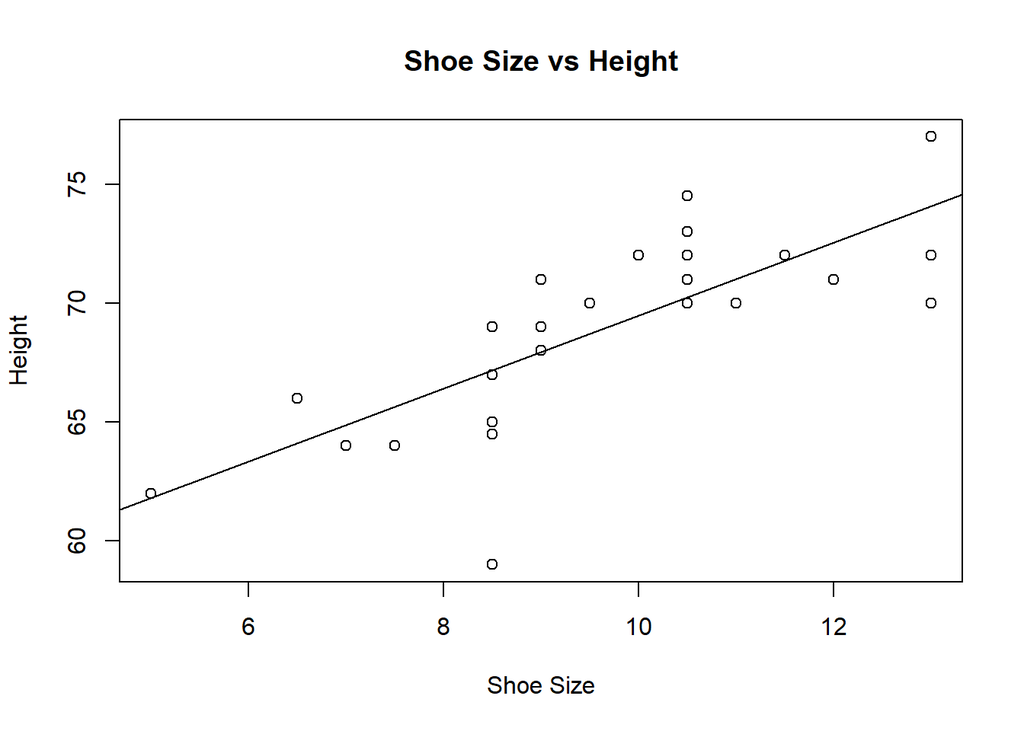

```r
plot(shoe_import$shoe_size, shoe_import$height,
     xlab = "Shoe Size", ylab = "Height",
     main = "Shoe Size vs Height")
abline(lm(height ~ shoe_size, data = shoe_import))
```

#Question #2

```r
shoe_import$gender <- factor(shoe_import$gender)

shoe_import$gender
```

```
##  [1] F F F F M F F F M F M F M M M M F F M F F M M F M M M M
## Levels: F M
```

```r
levels(shoe_import$gender)
```

```
## [1] "F" "M"
```

```r
str(shoe_import)
```

```
## 'data.frame':    28 obs. of  3 variables:
##  $ shoe_size: num  6.5 9 8.5 8.5 10.5 7 9.5 9 13 7.5 ...
##  $ height   : num  66 68 64.5 65 70 64 70 71 72 64 ...
##  $ gender   : Factor w/ 2 levels "F","M": 1 1 1 1 2 1 1 1 2 1 ...
```

The gender column was converted into a factor with two levels, F and M. Since gender is a nominal variable, the levels have no order, and neither one is worth more than the other.

#Question #3 R Markdown uses the folder containing the .Rmd file as the working directory, so relative file paths like “shoesize.csv” always point to the same place, no matter what folder the R console was in. When the file is shared with someone else, they can open it from any computer, and the import will still work as long as the data file is in the same folder. This makes the document reproducible, because it does not depend on one person’s own folder setup.

#Question #4

```r
shoe_import <- read.csv("shoesize.csv")
str(shoe_import)
```

```
## 'data.frame':    28 obs. of  3 variables:
##  $ shoe_size: num  6.5 9 8.5 8.5 10.5 7 9.5 9 13 7.5 ...
##  $ height   : num  66 68 64.5 65 70 64 70 71 72 64 ...
##  $ gender   : chr  "F" "F" "F" "F" ...
```

R assigned the gender column the type character (chr), which is what I expected because gender is text made of letters. If a numeric column like shoe_size was accidentally imported as character because of a stray non-numeric value, calculations such as mean(), sum(), and cor() would fail or give wrong results. Sorting would also use alphabetical order instead of numeric order, so “10.5” would come before “9.0”.

#Question #5

```r
head(shoe_import)
```

```
##   shoe_size height gender
## 1       6.5   66.0      F
## 2       9.0   68.0      F
## 3       8.5   64.5      F
## 4       8.5   65.0      F
## 5      10.5   70.0      M
## 6       7.0   64.0      F
```

```r
tail(shoe_import)
```

```
##    shoe_size height gender
## 23      10.5     73      M
## 24       8.5     69      F
## 25      10.5     72      M
## 26      11.0     70      M
## 27       9.0     69      M
## 28      13.0     70      M
```

Checking both head() and tail() is good practice because head() only shows the first rows, while problems often appear at the end of a file. For example, extra blank rows, a stray footer or note, or a row with a missing or misplaced value at the bottom would not show up in head() alone. tail() confirms that the whole file was imported correctly, including the last rows.

#Question #6 #a

```r
cor(shoe_import$shoe_size, shoe_import$height)
```

```
## [1] 0.7766089
```

The correlation between shoe size and height across all 28 observations is about 0.78, which is a strong positive relationship.

#b

```r
shoe_import[shoe_import$shoe_size >= 11, ]
```

```
##    shoe_size height gender
## 9       13.0     72      M
## 13      12.0     71      M
## 15      13.0     77      M
## 16      11.5     72      M
## 26      11.0     70      M
## 28      13.0     70      M
```

Six respondents have a shoe size of 11 or higher, and all of them are male.

#Question #7

```r
mean(females$shoe_size)
```

```
## [1] 7.857143
```

```r
mean(females$height)
```

```
## [1] 65.67857
```

```r
mean(males$shoe_size)
```

```
## [1] 10.96429
```

```r
mean(males$height)
```

```
## [1] 71.46429
```

```r
# optional: correlation within each group
cor(females$shoe_size, females$height)
```

```
## [1] 0.4923774
```

```r
cor(males$shoe_size, males$height)
```

```
## [1] 0.5188998
```

The males have a higher mean shoe size (about 10.96) and a higher mean height (about 71.46) than the females (about 7.86 and 65.68). This shows a pattern where the group with bigger shoe sizes is also taller.

Yes, the dataset supports a relationship within each gender group, since the correlation inside each group is positive (about 0.5). But it is weaker than the overall 0.78, which means gender is an important factor that must be accounted for separately. Part of the overall relationship comes from the males being both taller and having bigger feet.